# Machine Learnin Project - Human Activity Recognition

### Background

Using devices such as Jawbone Up, Nike FuelBand, and Fitbit it is now possible to collect a large amount of data about personal activity relatively inexpensively. These type of devices are part of the quantified self movement – a group of enthusiasts who take measurements about themselves regularly to improve their health, to find patterns in their behavior, or because they are tech geeks. One thing that people regularly do is quantify how much of a particular activity they do, but they rarely quantify how well they do it. In this project, your goal will be to use data from accelerometers on the belt, forearm, arm, and dumbell of 6 participants. They were asked to perform barbell lifts correctly and incorrectly in 5 different ways. More information is available from the website here: http://groupware.les.inf.puc-rio.br/har (see the section on the Weight Lifting Exercise Dataset)

### Getting and Cleaning Data - Selecting Feature Variables

Import the training and test data for the project

```r
train <- read.csv("http://d396qusza40orc.cloudfront.net/predmachlearn/pml-training.csv", na.strings=c("NA","#DIV/0!",""))
test <- read.csv("http://d396qusza40orc.cloudfront.net/predmachlearn/pml-testing.csv", na.strings=c("NA","#DIV/0!",""))
```

Looking into the test data set there are lots of complete NA variables which would not contribute to the prediction if used as feature variables. So these variables are removed from both train and test data sets.

```r
dim(test)
```

```
## [1]  20 160
```

```r
testnrow <- nrow(test)
# variables with NAs in all rows
NAcols <- names(test)[unlist(lapply(test, function(x) length(which(is.na(x)))==testnrow))]

# remove NA variables from data sets
test <- test[,-which(names(test) %in% NAcols)]
train <- train[,-which(names(train) %in% NAcols)]
str(train)
```

```
## 'data.frame':    19622 obs. of  60 variables:
##  $ X                   : int  1 2 3 4 5 6 7 8 9 10 ...
##  $ user_name           : Factor w/ 6 levels "adelmo","carlitos",..: 2 2 2 2 2 2 2 2 2 2 ...
##  $ raw_timestamp_part_1: int  1323084231 1323084231 1323084231 1323084232 1323084232 1323084232 1323084232 1323084232 1323084232 1323084232 ...
##  $ raw_timestamp_part_2: int  788290 808298 820366 120339 196328 304277 368296 440390 484323 484434 ...
##  $ cvtd_timestamp      : Factor w/ 20 levels "02/12/2011 13:32",..: 9 9 9 9 9 9 9 9 9 9 ...
##  $ new_window          : Factor w/ 2 levels "no","yes": 1 1 1 1 1 1 1 1 1 1 ...
##  $ num_window          : int  11 11 11 12 12 12 12 12 12 12 ...
##  $ roll_belt           : num  1.41 1.41 1.42 1.48 1.48 1.45 1.42 1.42 1.43 1.45 ...
##  $ pitch_belt          : num  8.07 8.07 8.07 8.05 8.07 8.06 8.09 8.13 8.16 8.17 ...
##  $ yaw_belt            : num  -94.4 -94.4 -94.4 -94.4 -94.4 -94.4 -94.4 -94.4 -94.4 -94.4 ...
##  $ total_accel_belt    : int  3 3 3 3 3 3 3 3 3 3 ...
##  $ gyros_belt_x        : num  0 0.02 0 0.02 0.02 0.02 0.02 0.02 0.02 0.03 ...
##  $ gyros_belt_y        : num  0 0 0 0 0.02 0 0 0 0 0 ...
##  $ gyros_belt_z        : num  -0.02 -0.02 -0.02 -0.03 -0.02 -0.02 -0.02 -0.02 -0.02 0 ...
```

[output cut: 46 more lines]

ID, timestamps and window variables are not related to movement and will not be included in the predictive feature set.

```r
train <- train[,-c(1:7)]
test <- test[,-c(1:7)]
dim(train)
```

```
## [1] 19622    53
```

### Model Selection

```r
summary(train$classe)
```

```
##    A    B    C    D    E
## 5580 3797 3422 3216 3607
```

Since the dataset is pretty balanced between classes the random forest model was chosen for the prediction. Some of the other features why the random forest was chosen as the best fit:

- Accuracy
- Runs efficiently on large datasets
- Handles thousands of input variables without variable deletion
- Gives estimates of what variables are important in the classification
- Generates an internal unbiased estimate of the generalization error as the forest building progresses

```r
library(caret)
library(randomForest)

set.seed(111)
modelFit <- randomForest(train$classe ~ ., data=train, importance=TRUE)
```

### Cross Validation

**The out-of-bag (oob) error estimate**

```r
modelFit
```

```
##
## Call:
##  randomForest(formula = train$classe ~ ., data = train, importance = TRUE)
##                Type of random forest: classification
##                      Number of trees: 500
## No. of variables tried at each split: 7
##
##         OOB estimate of  error rate: 0.25%
## Confusion matrix:
##      A    B    C    D    E class.error
## A 5578    1    0    0    1   0.0003584
## B   10 3784    3    0    0   0.0034238
## C    0    8 3413    1    0   0.0026300
## D    0    0   19 3194    3   0.0068408
## E    0    0    2    2 3603   0.0011090
```

### Conclusion

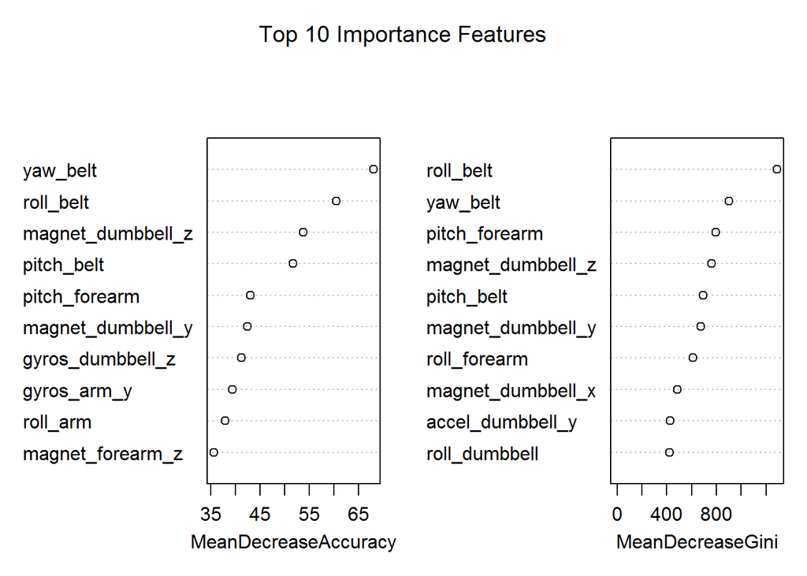

```r
varImpPlot(modelFit, n.var = 10, main="Top 10 Importance Features")
```

There’s two types of importance features shown above. The accuracy one tests to see how worse the model performs without each variable, so a high decrease in accuracy would be expected for very predictive variables. The Gini one digs into the mathematics behind decision trees, but essentially measures how pure the nodes are at the end of the tree. Again it tests to see the result if each variable is taken out and a high score means the variable was important.